# P1_practice_mid_term_hes_e106

Gurdeep

21/10/2020

```r
rm(list = ls())

setwd("/cloud/project/practice_mid_term") # change to local directory before running

library(knitr)
library(onewaytests)
library(olsrr)
library(lmtest)
library(MASS)
library(ALSM)
pmq1 <- read.csv('PM Q1.csv')
head(pmq1)
```

```
##        Y    X
## 1 360000 3032
## 2 340000 2058
## 3 250000 1780
## 4 205500 1638
## 5 275500 2196
## 6 248000 1966
```

```r
colnames(pmq1)
```

```
## [1] "Y" "X"
```

```r
dim(pmq1)
```

```
## [1] 522   2
```

1a. a- ) Build a regression model to predict Y as a function of X. Write down the regression model, Is the regression model significant? (5 points)

```r
reg1a <- lm(Y~X, data = pmq1)
summary(reg1a)
```

```
##
## Call:
## lm(formula = Y ~ X, data = pmq1)
##
## Residuals:
##     Min      1Q  Median      3Q     Max
## -239405  -39840   -7641   23515  388362
##
## Coefficients:
##               Estimate Std. Error t value Pr(>|t|)
## (Intercept) -81432.946  11551.846  -7.049 5.74e-12 ***
## X              158.950      4.875  32.605  < 2e-16 ***
## ---
## Signif. codes:  0 '***' 0.001 '**' 0.01 '*' 0.05 '.' 0.1 ' ' 1
##
## Residual standard error: 79120 on 520 degrees of freedom
## Multiple R-squared:  0.6715, Adjusted R-squared:  0.6709
## F-statistic:  1063 on 1 and 520 DF,  p-value: < 2.2e-16
```

```r
ei_p1 <- reg1a$residuals
```

The regression model is Y = -81432.946 + 158.950 * X

The model has F-statistic of 1063 with p-value < 2.2e-16. Individual coefficients also have small p-values. This leads us to interpret that the model is significant.

1b. b-) Check all the assumptions related to the regression model and perform Brown-Forsythe Test. (10 points)

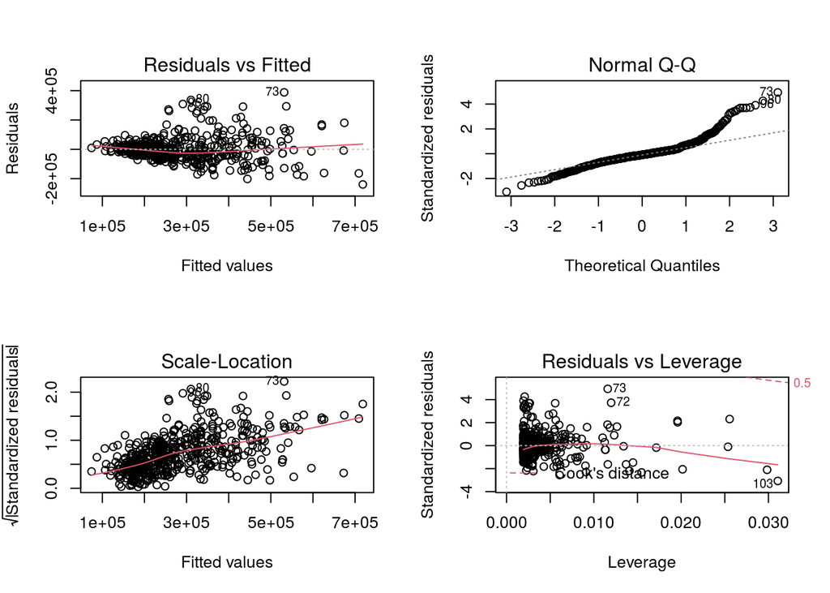

```r
# plot residuals and other standard plots
old.par <- par(mfrow = c(2,2))
plot(reg1a)
```

```r
old.par
```

```
## $mfrow
## [1] 1 1
```

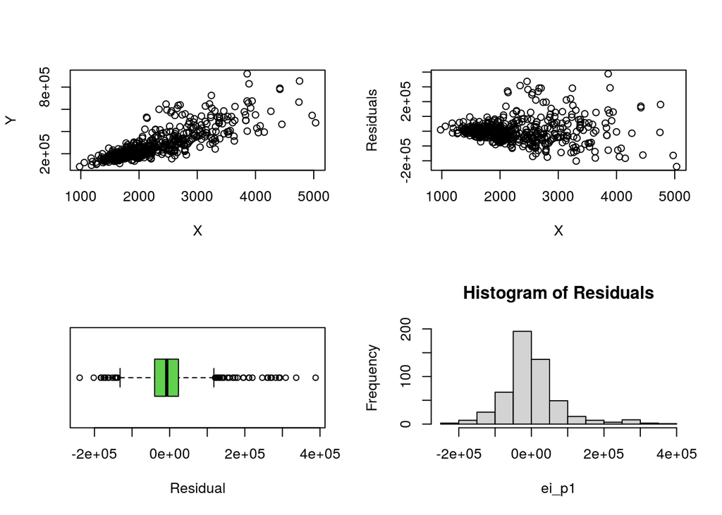

```r
newer.par = par(mfrow = c(2,2))
plot(pmq1$X, pmq1$Y, xlab = 'X', ylab = 'Y')
plot(pmq1$X,ei_p1, xlab = 'X', ylab = 'Residuals')
boxplot(ei_p1, horizontal = TRUE, staplewax = 0.5, col = 3, xlab = 'Residual')
hist(ei_p1, main = 'Histogram of Residuals')
```

```r
newer.par
```

```
## $mfrow
## [1] 2 2
```

```r
# BF test
bf.data <- data.frame(cbind(pmq1, reg1a$residuals, reg1a$fitted.values))
colnames(bf.data)
```

```
## [1] "Y"                   "X"                   "reg1a.residuals"
## [4] "reg1a.fitted.values"
```

```r
dimnames(bf.data)[[2]][3:4] <- c('residuals', 'fitted.values')
colnames(bf.data)
```

```
## [1] "Y"             "X"             "residuals"     "fitted.values"
```

```r
bf.data1 <- data.frame(cbind(bf.data, ind = as.factor(I(bf.data$X<=median(bf.data$X))*1)))
dim(bf.data1) # Indicator column added at end
```

```
## [1] 522   5
```

```r
bf.test(residuals~ind, data = bf.data1)
```

```
##
##   Brown-Forsythe Test (alpha = 0.05)
## -------------------------------------------------------------
##   data : residuals and ind
##
##   statistic  : 0.389263
##   num df     : 1
##   denom df   : 312.1958
##   p.value    : 0.5331427
##
##   Result     : Difference is not statistically significant.
## -------------------------------------------------------------
```

From the residuals vs fitted plot we see that residuals diverge as X value increases. This pattern is also seen in the plot of X vs Y and Residuals vs X. From Q-Q plot we see that the actual vs expected frequencies line is not 45 degrees and that the residuals plot diverges after 1.5 SD There is presence of outliers Boxplot is not symmetrical with many outliers. Histogram of residuals has a long right tail.

1c-)Do we need to transform Y? Use Box-Cox procedure to find out appropriate transformation of Y and justify your choice. (10 points)

From the scatterplot of X and Y we see that the Y values for higher values of X are dispersed. This indicates that some transformation is needed. We explore with BoxCox below

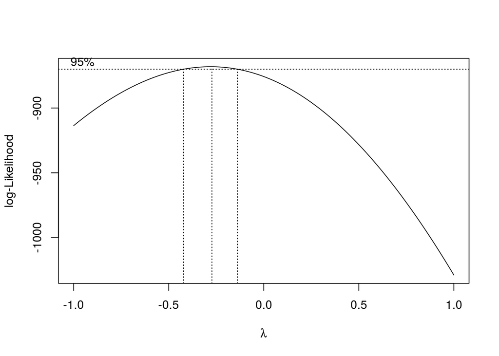

```r
boxcox(reg1a, lambda = seq(-1.0, 1.0,0.1))
```

The results are in the middle of lambda = 0 implying log (Y) and lambda = -0.5 implying 1/sqrt(Y). We explore both transformation. For transformation of X we try log transform to allow for dispersion.

```r
# explore log transform of both X & Y
reg1c_1 <- lm(log(Y)~log(X), data = pmq1)
summary(reg1c_1)
```

```
##
## Call:
## lm(formula = log(Y) ~ log(X), data = pmq1)
##
## Residuals:
##      Min       1Q   Median       3Q      Max
## -0.69646 -0.13693 -0.00739  0.12315  0.78141
##
## Coefficients:
##             Estimate Std. Error t value Pr(>|t|)
## (Intercept)  2.79630    0.25930   10.78   <2e-16 ***
## log(X)       1.25518    0.03374   37.20   <2e-16 ***
## ---
## Signif. codes:  0 '***' 0.001 '**' 0.01 '*' 0.05 '.' 0.1 ' ' 1
##
## Residual standard error: 0.2258 on 520 degrees of freedom
## Multiple R-squared:  0.7268, Adjusted R-squared:  0.7263
## F-statistic:  1384 on 1 and 520 DF,  p-value: < 2.2e-16
```

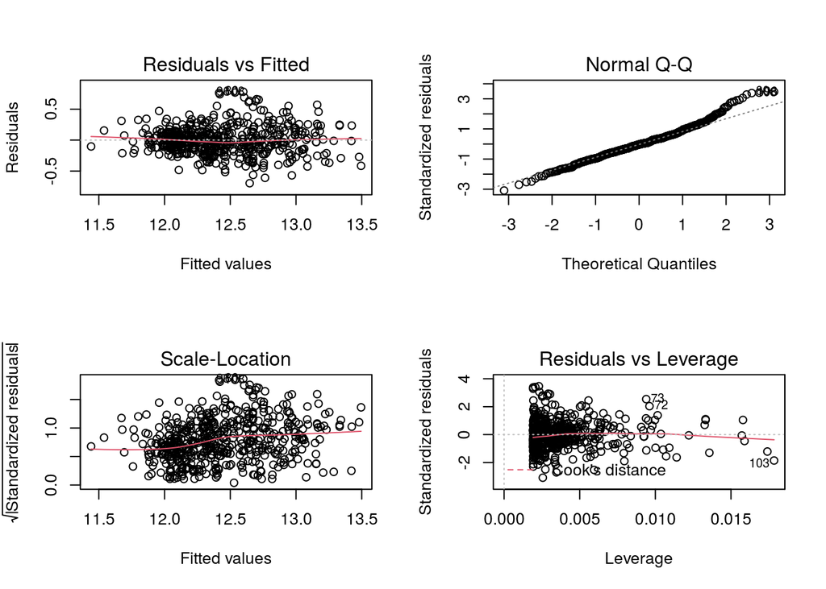

```r
ei_1c_1 <- reg1c_1$residuals

# plot residuals and other standard plots
old.par <- par(mfrow = c(2,2))
plot(reg1c_1)
```

```r
old.par
```

```
## $mfrow
## [1] 1 1
```

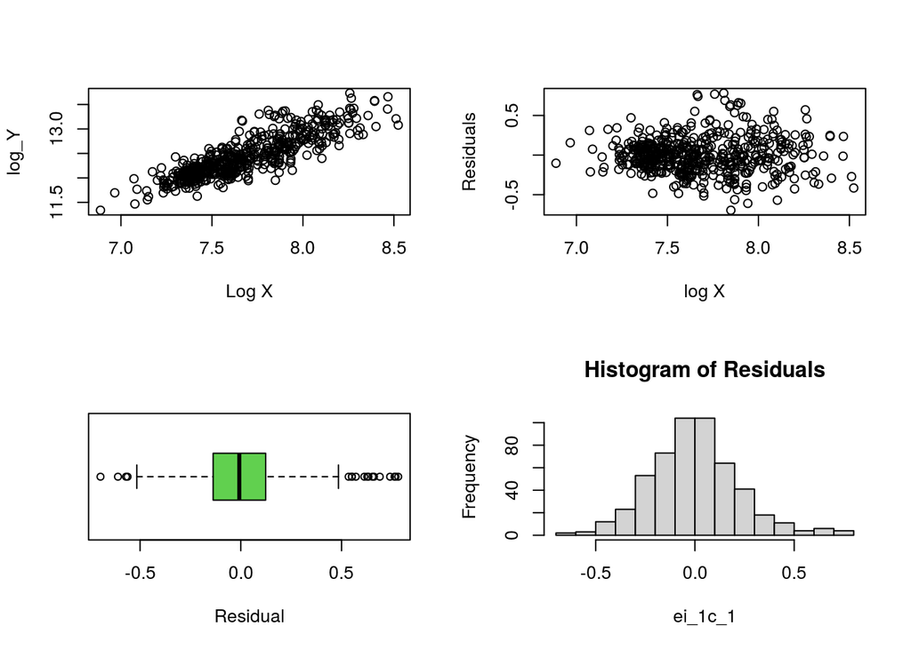

```r
newer.par = par(mfrow = c(2,2))
plot(log(pmq1$X), log(pmq1$Y), xlab = 'Log X', ylab = 'log_Y')
plot(log(pmq1$X),ei_1c_1, xlab = 'log X', ylab = 'Residuals')
boxplot(ei_1c_1, horizontal = TRUE, staplewax = 0.5, col = 3, xlab = 'Residual')
hist(ei_1c_1, main = 'Histogram of Residuals')
```

```r
newer.par
```

```
## $mfrow
## [1] 2 2
```

```r
# explore transformation 1/sqrt(Y) and log(X)
reg_1c_2 <- lm(1/sqrt(Y)~log(Y), data = pmq1)
summary(reg_1c_2)
```

```
##
## Call:
## lm(formula = 1/sqrt(Y) ~ log(Y), data = pmq1)
##
## Residuals:
##        Min         1Q     Median         3Q        Max
## -4.688e-05 -3.860e-05 -1.585e-05  2.132e-05  3.671e-04
##
## Coefficients:
##               Estimate Std. Error t value Pr(>|t|)
## (Intercept)  1.388e-02  6.619e-05   209.7   <2e-16 ***
## log(Y)      -9.524e-04  5.320e-06  -179.0   <2e-16 ***
## ---
## Signif. codes:  0 '***' 0.001 '**' 0.01 '*' 0.05 '.' 0.1 ' ' 1
##
## Residual standard error: 5.242e-05 on 520 degrees of freedom
## Multiple R-squared:  0.984,  Adjusted R-squared:  0.984
## F-statistic: 3.205e+04 on 1 and 520 DF,  p-value: < 2.2e-16
```

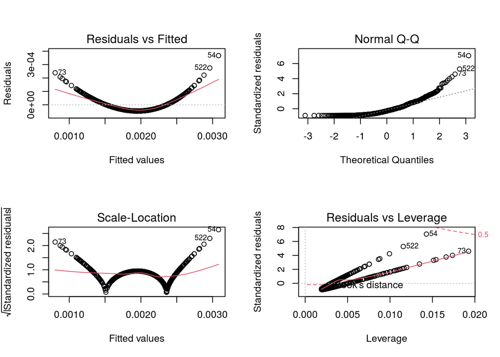

```r
ei_1c_2 <- reg_1c_2$residuals

# plot residuals and other standard plots
old.par <- par(mfrow = c(2,2))
plot(reg_1c_2)
```

```r
old.par
```

[output not shown]

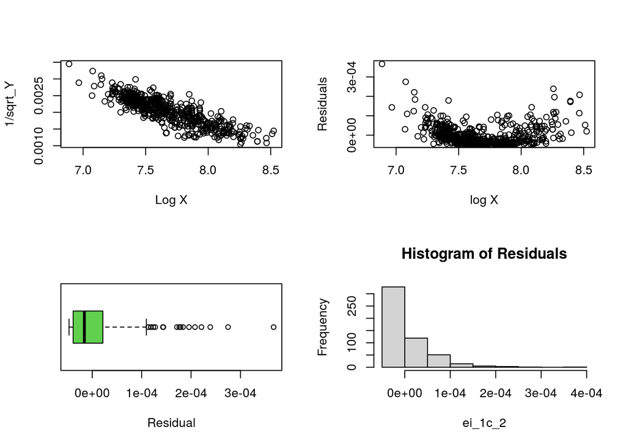

```r
newer.par = par(mfrow = c(2,2))
plot(log(pmq1$X), 1/sqrt(pmq1$Y), xlab = 'Log X', ylab = '1/sqrt_Y')
plot(log(pmq1$X),ei_1c_2, xlab = 'log X', ylab = 'Residuals')
boxplot(ei_1c_2, horizontal = TRUE, staplewax = 0.5, col = 3, xlab = 'Residual')
hist(ei_1c_2, main = 'Histogram of Residuals')
```

```r
newer.par
```

```
## $mfrow
## [1] 2 2
```

From the plots above we see that the log transform of both variables is the final model.The 2nd transform of 1/sqrt(Y) has very high R2 which itself may be a problem, and the residual plots are also not in line.

1d-) Use the final model to predict Y for three new X values, 1100, 3000 and 4900. which methods would use you to calculate the joint 90% confidence intervals? Justify your choice and calculate the confidence interval using the final model in part c. (15 points)

We explore both bonferroni and working-hotelling methods for calculation of 90% jt CI

```r
xh <- c(1100, 3000, 4900)
# make prediction
pred <- predict.lm(reg1c_1, data.frame(X = xh), level = 0.90, se.fit = TRUE)
pred
```

```
## $fit
##        1        2        3
## 11.58642 12.84574 13.46156
##
## $se.fit
##          1          2          3
## 0.02485250 0.01482712 0.02932326
##
## $df
## [1] 520
##
## $residual.scale
## [1] 0.2258249
```

```r
# bonferroni method
b <- rep(qt(1-0.90/(2*length(xh)), nrow(pmq1)-2), length(xh))
b
```

```
## [1] 1.037468 1.037468 1.037468
```

```r
bonf_final <- rbind(exp(pred$fit) - b*(exp(pred$se.fit)), exp(pred$fit) + b*exp(pred$se.fit))
bonf_final
```

```
##             1        2        3
## [1,] 107624.8 379169.8 701910.4
## [2,] 107627.0 379171.9 701912.5
```

```r
# w-h method
w <- rep(sqrt(2*qf(0.90, 2, nrow(pmq1)-2)), length(xh)) # get f-value and repeat 3 times
wh_final <- rbind(exp(pred$fit) - w*exp(pred$se.fit), exp(pred$fit) + w*exp(pred$se.fit)) # yhat + & - (W * SE of prediction)
wh_final
```

```
##             1        2        3
## [1,] 107623.7 379168.6 701909.2
## [2,] 107628.1 379173.0 701913.7
```

```r
# compare both methods
bonf_final[2,1:3] - bonf_final[1,1:3]
```

```
##        1        2        3
## 2.127149 2.105930 2.136681
```

```r
wh_final[2,1:3] - wh_final[1,1:3]
```

```
##        1        2        3
## 4.409693 4.365705 4.429452
```

Since the bonferroni interval is narrower than the WH interval we use the bonferroni interval as the final interval.